# Data Visualization / Group Project 8(A)

Alicia Mañas, Paula Artiz and Lidia Sánchez

2026-03-5

# Part A

### 1. Where and why was the information collected?

```r
# The information was extracted from ancient DNA samples cataloged in Table S1 of the 2018 Science article “The evolutionary history of dogs in the Americas” by Máire Ní Leathlobhair and other authors (2018).

# Reference: Ní Leathlobhair, M., Perri, A. R., Irving-Pease, E. K., Witt, K. E., Linderholm, A., Haile, J., Lebrasseur, O., Ameen, C., Blick, J., Boyko, A. R., Brace, S., Cortes, Y. N., Crockford, S. J., Devault, A., Dimopoulos, E. A., Eldridge, M., Enk, J., Gopalakrishnan, S., … Frantz, L. A. F. (2018). The evolutionary history of dogs in the Americas. Science, 361(6397), 81–85. https://doi.org/10.1126/science.aao4776
```

### 2. Which is the meaning of each variable?

[output not shown]

### 3. Do the variables have units? Which one?

```r
#Yes, some variables have units.
```

| Variable | Unit |
| --- | --- |
| Long, Lat | Decimal degrees |
| Age | Years |
| Number of reads | Number of reads |
| Radiocarbon date | Years |
| Percentage of endogenous | % |
| Nuclear coverage | x-fold coverage |
| N_SNP_call | Number SNP |
| mtDNA Coverage | x-fold coverage |

### 4. Does the data set have a long format?

```r
# No, it has a wide format as multiple measurements of a single observation are stored in a single row.
```

### 5. Read the excel file into R

In this step, we upload the data of the Excel file and we ensure the names of the columns stay as the header while deleting the first informative row:

```r
excel_route <- "aao4776_tables1.xlsx" # The .xlsx file is uploaded with the task, so you may need to modify the file path depending on where you save it.
df <- read_excel(excel_route, skip = 1)
head(df)
```

```
## # A tibble: 6 × 21
##   Extract_ID Depository_ID        `Dog/Wolf Status` Country `Site name`
##   <chr>      <chr>                <chr>             <chr>   <chr>
## 1 JBG43      11S1232 I15 PP4747-1 Dog               USA     Janey B. Goode, Ill…
## 2 JBG41      11S1232 7892-1       Dog               USA     Janey B. Goode, Ill…
## 3 JBG17      11S1232 2601-1       Dog               USA     Janey B. Goode, Ill…
## 4 JBG11      11S1232 1671-1       Dog               USA     Janey B. Goode, Ill…
## 5 JBG42      11S1232 F9 PP4407-1  Dog               USA     Janey B. Goode, Ill…
## 6 JBG13      11S1232 939-1        Dog               USA     Janey B. Goode, Ill…
## # ℹ 16 more variables: `Analysed\nNuclear` <dbl>, `mtDNA \nAnalysed` <dbl>,
## #   `mtDNA capture` <dbl>, Extraction_lab <chr>, Lat <dbl>, Long <dbl>,
## #   `Radiocarbon Lab #` <chr>, `Direct date?` <chr>,
## #   `Radiocarbon date \n (95.4% interval, lab number)` <chr>,
## #   `Age \n(from context)` <chr>, `Number \nof reads` <dbl>,
## #   `Endogeneous\n Content` <dbl>, `Nuclear\nCoverage` <chr>, Sex <chr>,
## #   `mtDNA \nCoverage` <dbl>, N_SNP_call <chr>
```

### 6. Reshape the data if necessary in long format

```r
str(df)
```

```
## tibble [98 × 21] (S3: tbl_df/tbl/data.frame)
##  $ Extract_ID                                      : chr [1:98] "JBG43" "JBG41" "JBG17" "JBG11" ...
##  $ Depository_ID                                   : chr [1:98] "11S1232 I15 PP4747-1" "11S1232 7892-1" "11S1232 2601-1" "11S1232 1671-1" ...
##  $ Dog/Wolf Status                                 : chr [1:98] "Dog" "Dog" "Dog" "Dog" ...
##  $ Country                                         : chr [1:98] "USA" "USA" "USA" "USA" ...
##  $ Site name                                       : chr [1:98] "Janey B. Goode, Illinois" "Janey B. Goode, Illinois" "Janey B. Goode, Illinois" "Janey B. Goode, Illinois" ...
##  $ Analysed
## Nuclear                               : num [1:98] 0 0 0 0 0 0 0 0 0 0 ...
##  $ mtDNA
## Analysed                                : num [1:98] 1 1 1 1 1 1 1 1 1 1 ...
##  $ mtDNA capture                                   : num [1:98] 1 1 1 1 1 1 1 1 1 1 ...
##  $ Extraction_lab                                  : chr [1:98] "Copenhagen" "Copenhagen" "Copenhagen" "Copenhagen" ...
##  $ Lat                                             : num [1:98] 38.7 38.7 38.7 38.7 38.7 ...
##  $ Long                                            : num [1:98] -90.2 -90.2 -90.2 -90.2 -90.2 ...
##  $ Radiocarbon Lab #                               : chr [1:98] "NA" "NA" "NA" "NA" ...
##  $ Direct date?                                    : chr [1:98] "NA" "NA" "NA" "NA" ...
##  $ Radiocarbon date
##  (95.4% interval, lab number): chr [1:98] "NA" "NA" "NA" "NA" ...
##  $ Age
## (from context)                            : chr [1:98] "1000-1400 BP" "1000-1400 BP" "1000-1400 BP" "1000-1400 BP" ...
##  $ Number
## of reads                               : num [1:98] 670175 164370 41931 130420 152682 ...
##  $ Endogeneous
##  Content                           : num [1:98] 64.5 37.7 79.2 53.8 60.7 ...
##  $ Nuclear
## Coverage                               : chr [1:98] "NA" "NA" "NA" "NA" ...
##  $ Sex                                             : chr [1:98] "NA" "NA" "NA" "NA" ...
##  $ mtDNA
## Coverage                                : num [1:98] 193 169 165 163 158 ...
##  $ N_SNP_call                                      : chr [1:98] "NA" "NA" "NA" "NA" ...
```

```r
sapply(df, class)
```

```
##                                       Extract_ID
##                                      "character"
##                                    Depository_ID
##                                      "character"
##                                  Dog/Wolf Status
##                                      "character"
##                                          Country
##                                      "character"
##                                        Site name
##                                      "character"
##                                Analysed\nNuclear
##                                        "numeric"
##                                 mtDNA \nAnalysed
##                                        "numeric"
##                                    mtDNA capture
##                                        "numeric"
##                                   Extraction_lab
##                                      "character"
##                                              Lat
##                                        "numeric"
##                                             Long
##                                        "numeric"
##                                Radiocarbon Lab #
##                                      "character"
##                                     Direct date?
##                                      "character"
## Radiocarbon date \n (95.4% interval, lab number)
##                                      "character"
##                             Age \n(from context)
##                                      "character"
##                                Number \nof reads
##                                        "numeric"
##                            Endogeneous\n Content
##                                        "numeric"
##                                Nuclear\nCoverage
##                                      "character"
##                                              Sex
##                                      "character"
##                                 mtDNA \nCoverage
##                                        "numeric"
##                                       N_SNP_call
##                                      "character"
```

### 7. Check the variable classes and update them if necessary

We can also see that some variable classes are wrongly adjusted, per example the Dog status is stated as a character or we can see binary variables as numeric.

```r
# We convert the "NA" in actual NA
df[df == "NA"] <- NA
```

```r
df <- df %>%
  mutate(

    extract_id = as.character(extract_id),
    depository_id = as.character(depository_id),
    site_name = as.character(site_name),


    dog_wolf_status = as.factor(dog_wolf_status),
    country = as.factor(country),
    extraction_lab = as.factor(extraction_lab),
    sex = as.factor(sex),

    analysed_nuclear = as.factor(analysed_nuclear),
    mt_dna_analysed = as.factor(mt_dna_analysed),
    mt_dna_capture = as.factor(mt_dna_capture),
    direct_date = as.factor(direct_date),

    lat = as.numeric(lat),
    long = as.numeric(long),
    number_of_reads = as.numeric(number_of_reads),
    endogeneous_content = as.numeric(endogeneous_content),
    nuclear_coverage = as.numeric(nuclear_coverage),
    mt_dna_coverage = as.numeric(mt_dna_coverage),
    n_snp_call = as.numeric(n_snp_call)
    )
```

Finally, we can see our new data frame

```r
df
```

[output not shown]

# Part B

### 1. Represent the distribution of the variables: pick one continuous variable and one discrete variable and use histograms or bar graphs to show their distribution

```r
library(ggplot2) # Needed to use ggplot function

# We have changed some columns names to avoid problems

colnames(df)[colnames(df) == "Extract_ID"] <- "extract_id"
colnames(df)[colnames(df) == "Depository_ID"] <- "depository_id"
colnames(df)[colnames(df) == "Dog/Wolf Status"] <- "dog_wolf_status"
colnames(df)[colnames(df) == "Country"] <- "country"
colnames(df)[colnames(df) == "Site name"] <- "site_name"
colnames(df)[colnames(df) == "Analysed\nNuclear"] <- "analysed_nuclear"
colnames(df)[colnames(df) == "mtDNA \nAnalysed"] <- "mt_dna_analysed"
colnames(df)[colnames(df) == "mtDNA capture"] <- "mt_dna_capture"
colnames(df)[colnames(df) == "Extraction_lab"] <- "extraction_lab"
colnames(df)[colnames(df) == "Lat"] <- "lat"
colnames(df)[colnames(df) == "Long"] <- "long"
colnames(df)[colnames(df) == "Radiocarbon Lab #"] <- "radiocarbon_lab_number"
colnames(df)[colnames(df) == "Direct date?"] <- "direct_date"
colnames(df)[colnames(df) == "Radiocarbon date \n (95.4% interval, lab number)"] <- "radiocarbon_date_95ci"
colnames(df)[colnames(df) == "Age \n(from context)"] <- "age_from_context"
colnames(df)[colnames(df) == "Number \nof reads"] <- "number_of_reads"
colnames(df)[colnames(df) == "Endogeneous\n Content"] <- "endogeneous_content"
colnames(df)[colnames(df) == "Nuclear\nCoverage"] <- "nuclear_coverage"
colnames(df)[colnames(df) == "Sex"] <- "sex"
colnames(df)[colnames(df) == "mtDNA \nCoverage"] <- "mt_dna_coverage"
colnames(df)[colnames(df) == "N_SNP_call"] <- "n_snp_call"
```

# Plot 1 -> Number of Reads (Continuous) & Country (Discrete)

### Helpful for visualizing how sequencing depth varies across different countries or geographic regions.

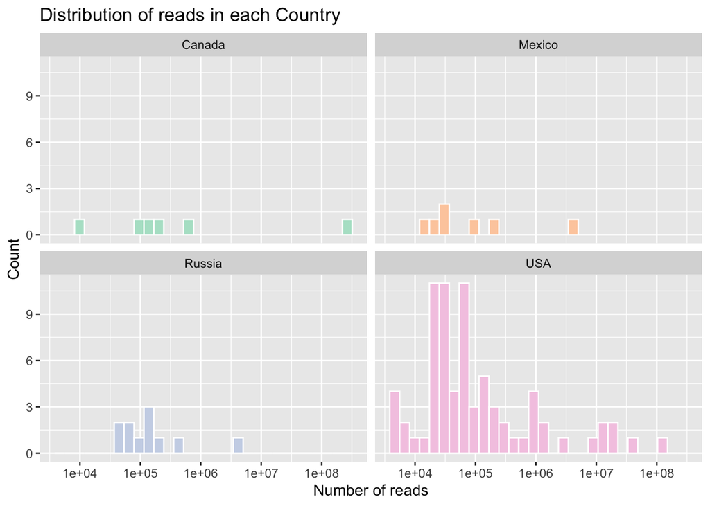

```r
ggplot(df, aes(x = number_of_reads,fill = country)) + geom_histogram(bins = 30,color = "white") + scale_x_log10() + facet_wrap(~country) +scale_fill_brewer(palette = "Pastel2") + labs(title = "Distribution of reads in each Country", x ="Number of reads", y= "Count") + theme_get() +theme(legend.position = "none")
```

# Plot 2 -> Endogenous Content (Continuous) & Dog/Wolf Status (Discrete)

### Allows comparison of ancient DNA preservation quality between dog and wolf samples.

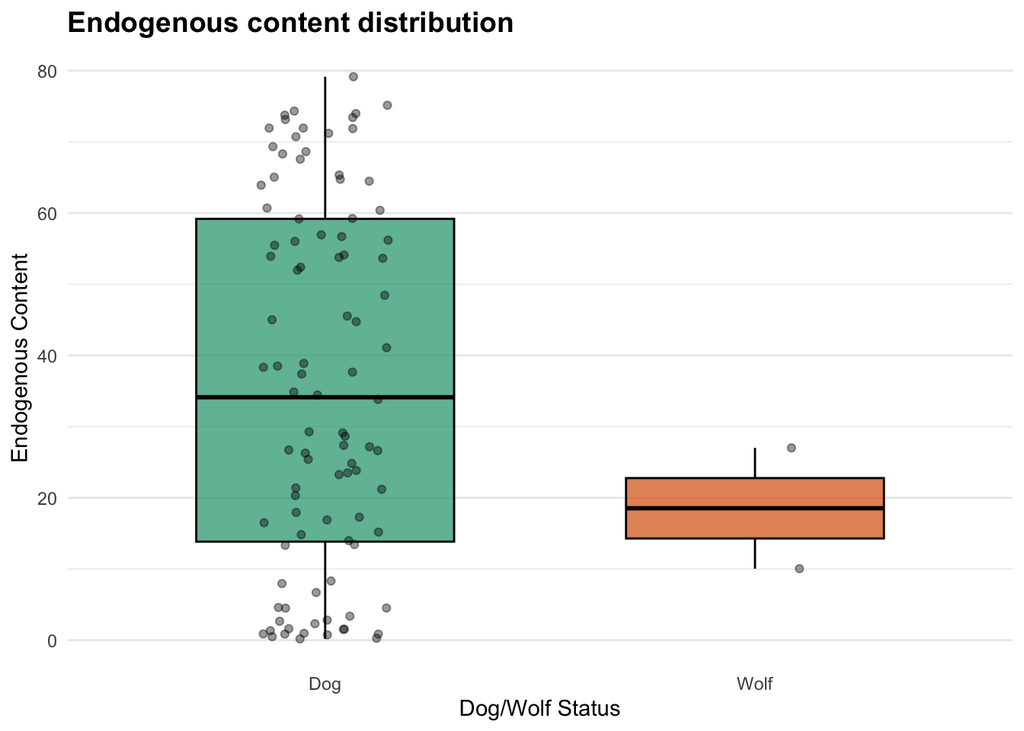

```r
ggplot(df, aes(x = dog_wolf_status, y = endogeneous_content,fill = dog_wolf_status)) + geom_boxplot(color = "black", alpha = 0.7, width = 0.6) +geom_jitter(width = 0.15, alpha = 0.4, show.legend = FALSE) + scale_fill_brewer(palette = "Dark2") + labs(title = "Endogenous content distribution", x ="Dog/Wolf Status", y = "Endogenous Content") + theme_minimal() + theme(legend.position = "none", panel.grid.major.x = element_blank(), plot.title = element_text(face = "bold", size = 14))
```

# Plot 3 -> mtDNA Coverage (Continuous) & Sex (Discrete)

### Enables assessment of whether mitochondrial DNA coverage differs between male and female specimens.

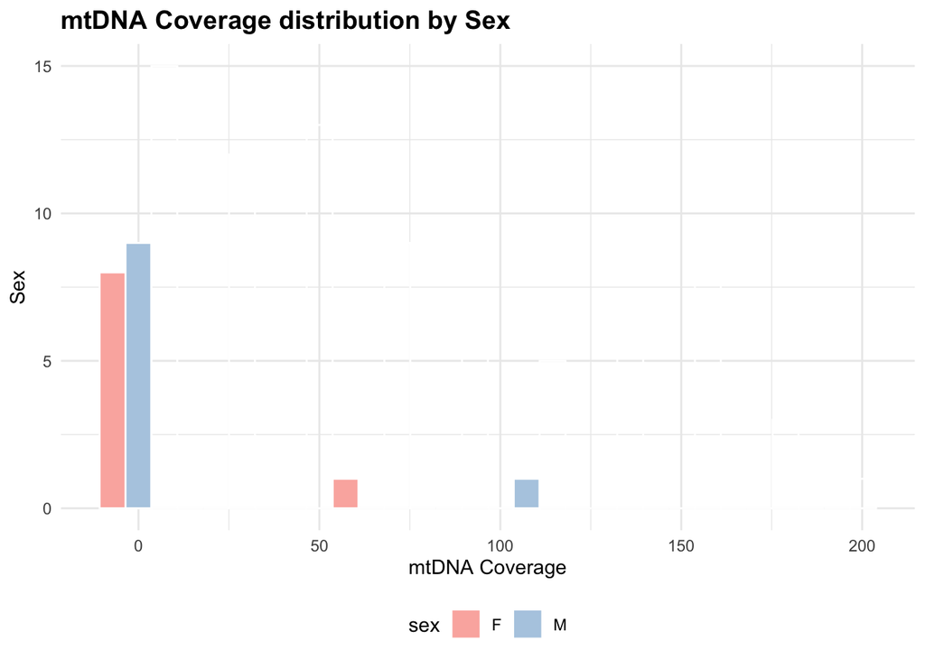

```r
ggplot(df, aes(x = mt_dna_coverage, fill = sex)) +geom_histogram(bins = 10, position = "dodge", color = "white") + scale_fill_brewer(palette = "Pastel1",na.value = "gray", na.translate =FALSE) + labs(title = "mtDNA Coverage distribution by Sex", x = "mtDNA Coverage", y = "Sex") + theme_minimal() + theme(legend.position ="bottom", plot.title = element_text(face = "bold", size = 14))
```

# Plot 4 -> Latitude (Continuous) & Country (Discrete)

### Visualizes the latitudinal position of samples categorized by their country of origin.

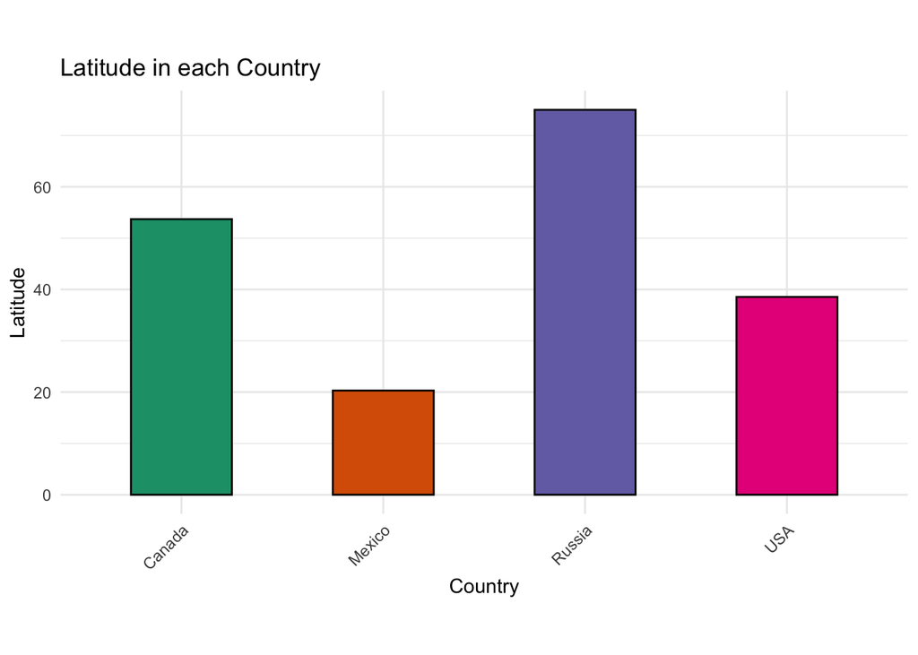

```r
df_summary <- df %>%
  group_by(country) %>%
  summarize(mean_lat = mean(lat, na.rm = TRUE))

ggplot(df_summary, aes(x = country, y = mean_lat, fill = country)) + geom_col(width = 0.5, color = "black") + scale_fill_brewer(palette = "Dark2") + labs(title = "Latitude in each Country", x = "Country", y = "Latitude") + theme_minimal() + theme(legend.position = "none", axis.text.x = element_text(angle = 45, hjust = 1), aspect.ratio = 0.5)
```

# Plot 5 -> N_SNP_call (Continuous) & mtDNA Capture (Discrete)

### Visualizes how the number of SNP calls varies depending on whether mtDNA capture was performed (1=Yes, 0=No).

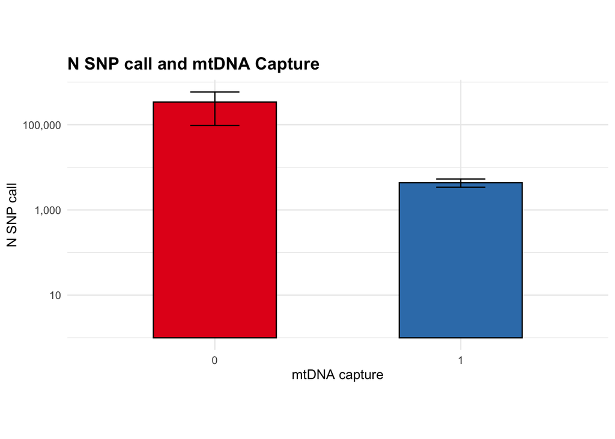

```r
df_plot5 <- df %>%
  group_by(mt_dna_capture) %>%
  summarize(
    mean_snp = mean(n_snp_call, na.rm = TRUE),
    se = sd(n_snp_call, na.rm = TRUE) / sqrt(n()))

ggplot(df_plot5, aes(x = mt_dna_capture, y = mean_snp, fill = mt_dna_capture)) + geom_col(width = 0.5, color = "black", alpha = 1) + geom_errorbar(aes(ymin = mean_snp - se, ymax = mean_snp + se), width = 0.2) + scale_y_log10(labels = scales::label_comma()) + scale_fill_brewer(palette = "Set1") + labs(title = "N SNP call and mtDNA Capture", x = "mtDNA capture", y = "N SNP call") + theme_minimal() + theme(legend.position = "none", plot.title = element_text(face = "bold", size = 14), aspect.ratio = 0.5)
```